# FIRST HOMEWORK: UNSUPERVISED LEARNING

Statistical Learning. Bachelor in Data Science and Engineering

Alejandro Leonardo García Navarro

November 3, 2022

# 1 Introduction to the homework.

The aim of this homework is to apply unsupervised learning tools to an open data set. Unsupervised learning is a collection of instruments for understanding data with no target attribute; that is, to discover hidden and interesting patterns in unlabeled data. In order to do so, it was proposed to think about some goals or questions that may be desired to answer and, finally, get convenient insights and conclusions from the output of the tools.

# 2 Information regarding the chosen dataset.

Before starting with the homework, it is of high vitality to both show and explain the basics of the chosen data set. This data set contains an airline passenger satisfaction survey and the main goal of it is to have a comprehensive understanding of what factors lead to customer satisfaction for an airline; that is, what factors are highly correlated to a satisfied or dissatisfied passenger?

It contains several variables. To be precise, 25:

- X: Refers to the number of row.
- ID: Identifier of each passenger.
- Gender: Gender of the passengers (Female, Male).
- Customer Type: The customer type (Loyal customer, disloyal customer).
- Age: The actual age of the passengers.
- Type of Travel: Purpose of the flight of the passengers (Personal Travel, Business Travel).
- Class: Travel class in the plane of the passengers (Business, Eco, Eco Plus).
- Flight distance: The flight distance of this journey.
- Inflight wifi service: Satisfaction level of the inflight wifi service (0:Not Applicable;1-5).
- Departure/Arrival time convenient: Satisfaction level of Departure/Arrival time convenient.
- Ease of Online booking: Satisfaction level of online booking.
- Gate location: Satisfaction level of Gate location.
- Food and drink: Satisfaction level of Food and drink.
- Online boarding: Satisfaction level of online boarding.
- Seat comfort: Satisfaction level of Seat comfort.
- Inflight entertainment: Satisfaction level of inflight entertainment.
- On-board service: Satisfaction level of On-board service.
- Leg room service: Satisfaction level of Leg room service.
- Baggage handling: Satisfaction level of baggage handling.
- Check-in service: Satisfaction level of Check-in service.
- Inflight service: Satisfaction level of inflight service.
- Cleanliness: Satisfaction level of Cleanliness.
- Departure Delay in Minutes: Minutes delayed when departure.
- Arrival Delay in Minutes: Minutes delayed when Arrival.
- Satisfaction: Airline satisfaction level (Satisfaction, neutral or dissatisfaction).

## 2.1 Loading dataset.

The data set is uploaded using the ‘read.csv’ function. It is known that the most common way that scientists store data is in Excel spreadsheets. While there are R packages designed to access data from Excel spreadsheets, it is often easier to save spreadsheets in comma-separated values files (CSV) and then use R’s built in functionality to read and manipulate the data.

```r
set.seed(123)
# STEP 1: Erase the global environment.
rm(list = ls())

# STEP 2: Install useful packages.
# Library that contains new tools for the visualization of missing values.
library(VIM)

# Library used for data visualization.
library(ggplot2)

# Library focused on tools for working with data frames.
library(dplyr)

# Library that is a collection of R packages designed for data science.
library(tidyverse)

# Library used to visualize and extract the output of multivariate data analyses.
library(factoextra)

# Library used for applying methods for cluster analysis.
library(cluster)

# Library that extends 'ggplot2'. Mainly used to make heatmap-like graphs.
library(GGally)

# Libraries used for clustering. In particular, the library 'mclust' is an
# R package for model-based clustering, classification, and density estimation
# based on finite normal mixture modelling.
library(cluster)
library(mclust)


# STEP 3: Load dataset.
passengers <- read.csv("passengers.csv")
dataset <- as.data.frame(passengers)
```

# 3 Data preprocessing.

Once the data is uploaded, the very first thing that must be carried out is the so-called ‘Data cleaning’. This is the process of fixing or removing incorrect corrupted, incorrectly formatted, duplicated, or incomplete data within a data set. There are several steps that must be followed.

## 3.1 STEP 1: Removing duplicated or irrelevant observations.

```r
# By observing the data set, it appears that, as of right now, two variables
# seem to be useless; 'X' and 'id'. First off, 'X' indicates the number of row.
# Consequently, is is deleted, since rows are already numbered. Moving on, as in
# this project it is not desired to analyze the passengers by themselves, but
# rather their answers to the surveys, the variable 'id'  can be omitted.
dataset$X <- NULL
dataset$id <- NULL

# Once irrelevant observations are deleted, it is now time to remove the
# duplicates, in case there are any. To do so, the function 'duplicated()'
# is used. It determines which elements of a vector or data frame are duplicates
# of elements with smaller subscripts, and returns a logical vector indicating
# which elements (rows) are duplicates.

# Moreover, due to the extent of this dataset, it will be impossible to recognize
# which rows contain 'TRUE' values just by observing it (the line duplicated(dataset)
# would be run in case this method was to be applied). Due to this exact purpose,
# other method is followed.

# Another dataset is created using '!duplicated()', where '!' indicates logical
# negation, so that a data set with no duplicates is obtained. Then, the original
# and the new data set are compared to know if there where duplicates or not.
data_unique <- dataset[!duplicated(dataset),]
identical(dataset, data_unique)
```

```
## [1] TRUE
```

```r
# Hence, as they are identical, there are no duplicates in the dataset.
```

## 3.2 STEP 2: Fix or remove typos or errors.

```r
# Having analyzed all the columns, no big typos or errors are spotted.
# Nonetheless, in order to provide a more straightforward output, the
# 'satisfaction' column is modified to have 'satisfied' and 'dissatisfied';
# instead of 'satisfied' and 'neutral or dissatisfied'.
dataset$satisfaction[dataset$satisfaction == "neutral or dissatisfied"] <- "dissatisfied"

# Furthermore, it is needed to take into account that the categorical variables
# must be transformed into factors. Factors are data structures in R that store
# categorical data. In datasets, there are often fields that take only a few
# predefined values. Hence, some modifications must be performed.
dataset$Gender = as.factor(dataset$Gender)
dataset$Customer.Type = as.factor(dataset$Customer.Type)
dataset$Type.of.Travel = as.factor(dataset$Type.of.Travel)
dataset$Class = as.factor(dataset$Class)
dataset$satisfaction = as.factor(dataset$satisfaction)
```

## 3.3 STEP 3: Outliers.

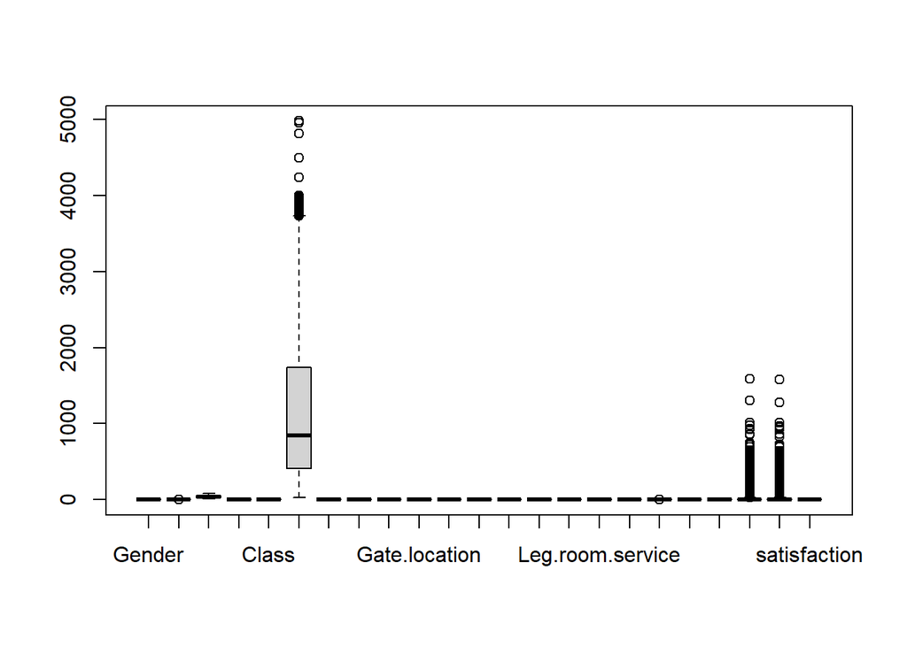

```r
# Before dealing with outliers, it is key to understand what these are. An
# outlier is an observation that lies an abnormal distance from other values
# in a random sample from a population (for example, if it is desired to study
# the weight of people an all the provided values ranges between 40kg-60kg,
# then, an outlier would be 700kg). There are several ways of checking these:
# either make a boxplot for every single variable or make a general boxplot for
# the entire dataset. The second method is followed.
boxplot(dataset)
```

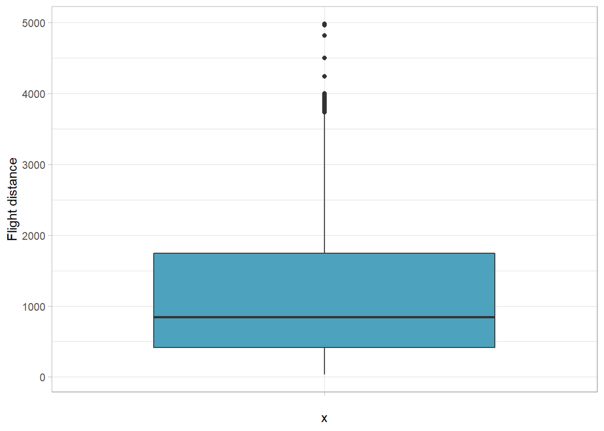

```r
# One can spot that variables like 'Flight.Distance', 'Checkin.service',
# 'Departure.Delay.in.Minutes' and 'Arrival.Delay.in.Minutes' contain outliers.
# Howbeit, a closer look in these variables is required to get better
# understandings and, therefore, take decisions.

# Variable 'Flight.Distance':
ggplot(dataset) +
  aes(x = "", y = Flight.Distance) +
  geom_boxplot(fill = "#4DA2BD") +
  labs(y = "Flight distance") +
  theme_light()
```

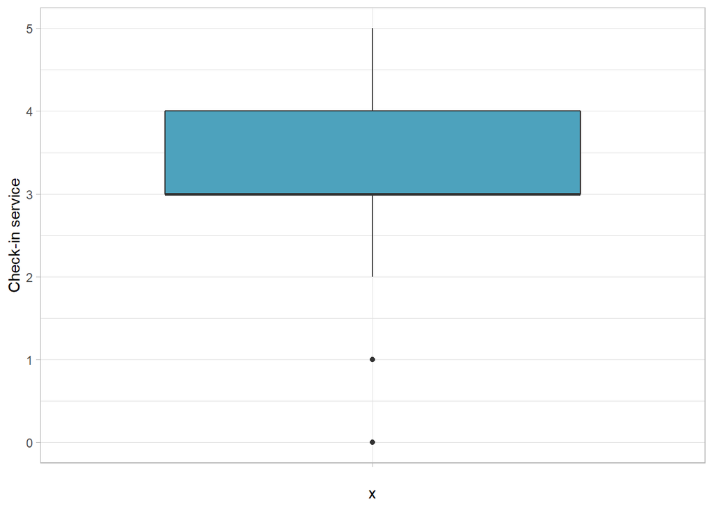

```r
# Variable 'Checkin.service':
ggplot(dataset) +
  aes(x = "", y = Checkin.service) +
  geom_boxplot(fill = "#4DA2BD") +
  labs(y = "Check-in service") +
  theme_light()
```

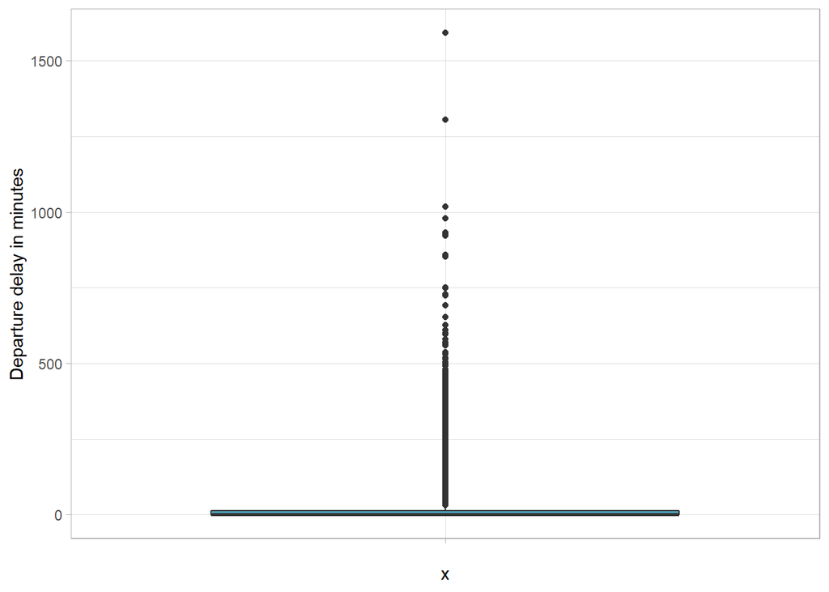

```r
# Variable 'Departure.Delay.in.Minutes':
ggplot(dataset) +
  aes(x = "", y = Departure.Delay.in.Minutes) +
  geom_boxplot(fill = "#4DA2BD") +
  labs(y = "Departure delay in minutes") +
  theme_light()
```

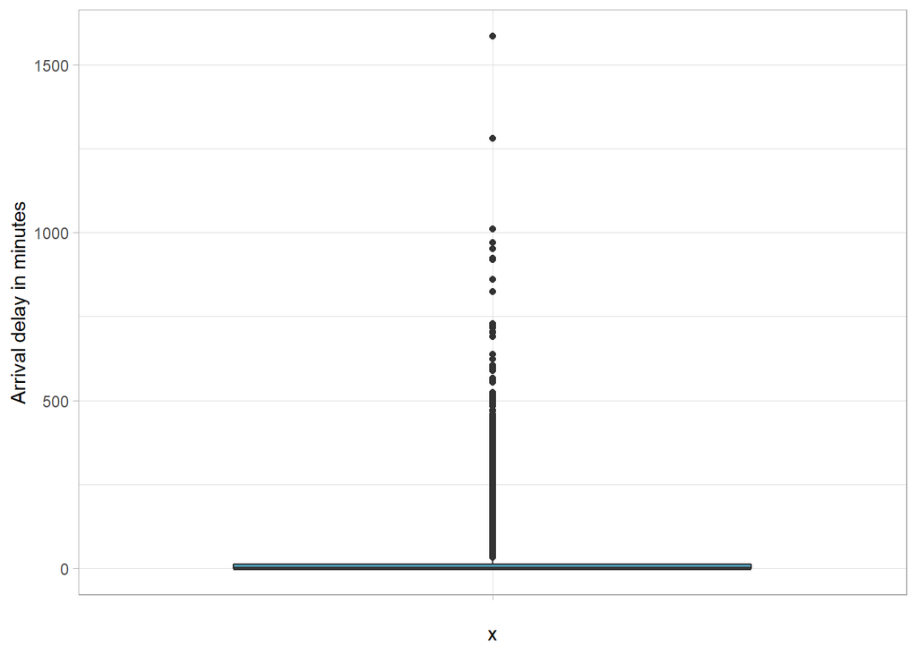

```r
# Variable 'Arrival.Delay.in.Minutes':
ggplot(dataset) +
  aes(x = "", y = Arrival.Delay.in.Minutes) +
  geom_boxplot(fill = "#4DA2BD") +
  labs(y = "Arrival delay in minutes") +
  theme_light()
```

```r
# Now it is in our hands to whether or not get rid of these values. After a
# considering time debating this, the decision of not deleting any of the
# outliers was taken. This is because these values may influence the rest,
# specially 'satisfaction', which constitutes a key pilar in the dataset.
```

## 3.4 STEP 4: Missing values.

```r
# A missing value is a non-present value in a variable. It is a must to identify
# them and decide what to do.
sum(is.na(dataset))
```

```
## [1] 310
```

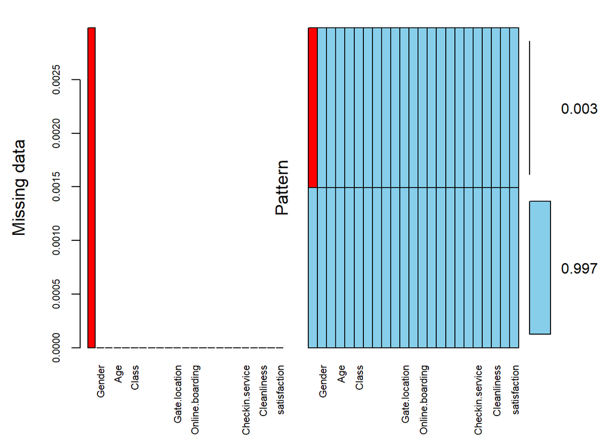

```
##
##  Variables sorted by number of missings:
##                           Variable       Count
##           Arrival.Delay.in.Minutes 0.002983523
##                             Gender 0.000000000
##                      Customer.Type 0.000000000
##                                Age 0.000000000
##                     Type.of.Travel 0.000000000
##                              Class 0.000000000
##                    Flight.Distance 0.000000000
##              Inflight.wifi.service 0.000000000
##  Departure.Arrival.time.convenient 0.000000000
##             Ease.of.Online.booking 0.000000000
##                      Gate.location 0.000000000
##                     Food.and.drink 0.000000000
##                    Online.boarding 0.000000000
##                       Seat.comfort 0.000000000
##             Inflight.entertainment 0.000000000
##                   On.board.service 0.000000000
##                   Leg.room.service 0.000000000
##                   Baggage.handling 0.000000000
##                    Checkin.service 0.000000000
##                   Inflight.service 0.000000000
##                        Cleanliness 0.000000000
##         Departure.Delay.in.Minutes 0.000000000
##                       satisfaction 0.000000000
```

```r
# With the help of the function 'aggr()', it is possible to visually see which
# specific variables contain empty values.
aggr(dataset, numbers = TRUE, sortVars = TRUE, labels = names(dataset),
     cex.axis = .7, gap = 1, ylab= c('Missing data','Pattern'))
```

```r
# As demonstrated, the missing values are on the 'Arrival.Delay.in.Minutes' variable.

# The next step is to determine what to do.
# As stated in class, if they are just a few and not relevant, we can delete them.
# Say less than 5% of the sample. Otherwise:
# 1. We can remove rows when most of their corresponding variables are empty.
# 1. We can remove columns when most of their corresponding rows are empty.

# In this case, "310" is less than 5% of the sample. In consequence, the decision
# of removing these is taken.
final_dataset <- na.omit(dataset)
```

# 4 Visualization tools to get insights before the tools.

For this part, it is basically asked to perform an exploratory data analysis. This refers to the critical process of performing initial investigations on data so as to discover patterns, to spot anomalies, to test hypothesis and to check assumptions with the help of summary statistics and graphical representations.

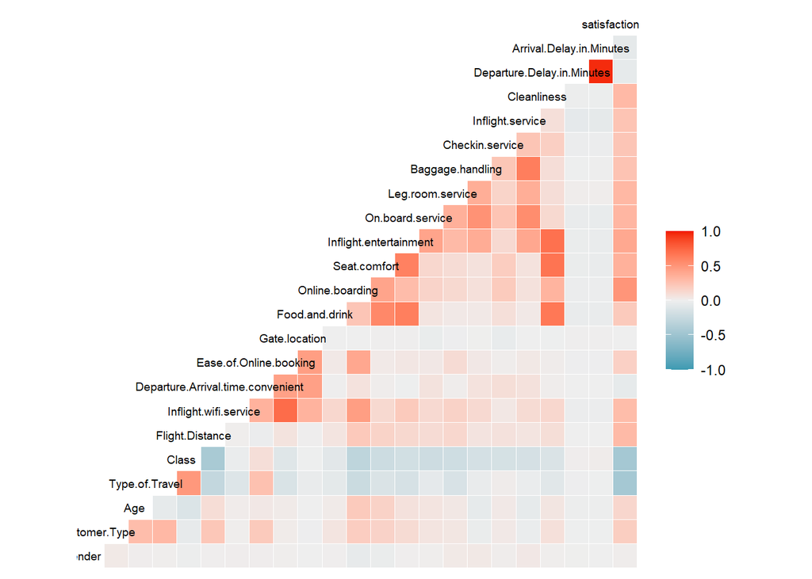

```r
# A step of high vitality to perform is to obtain a heatmap that shows us how
# related are the variables among them. With this, certain queries can be
# proposed and, hence, be able to fully understand the relation among the
# variables contained in the dataset.

data_heatmap <- as.data.frame(sapply(final_dataset, as.numeric))
ggcorr(data_heatmap, hjust = 0.75, size = 2.5)
```

```r
# This heatmap shows the correlation coefficients among all the variables.
# The correlation coefficient is a statistical measure of the strength of a
# linear relationship between two variables. Its values can range from -1 to 1:
# - A correlation coefficient of -1 describes a perfect negative correlation.
# - A coefficient of 1 shows a perfect positive correlation.
# - A correlation coefficient of 0 means there is no linear relationship.

# Furthermore, as illustrated, variables along the lines of 'Inflight.wifi.service',
#'Food.and.Drink' or even 'Seat.comfort' are worth studying.
```

For this part of the project, several questions are proposed to get valuable information from the variables, as well as check if certain values of one variable directly affects the values of other.

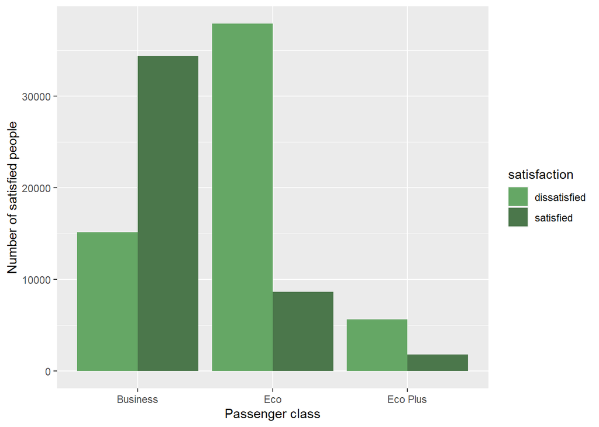

```r
# Q1: Is the travel class in somehow related to the satisfaction of the passengers?
# If so, which class is the most satisfied?
ggplot(final_dataset) + aes(x = Class, fill = satisfaction) +
  geom_bar(position = 'dodge') +
  xlab('Passenger class') + ylab('Number of satisfied people') +
  scale_fill_manual(values = c("#65a765", "#4B774B"))
```

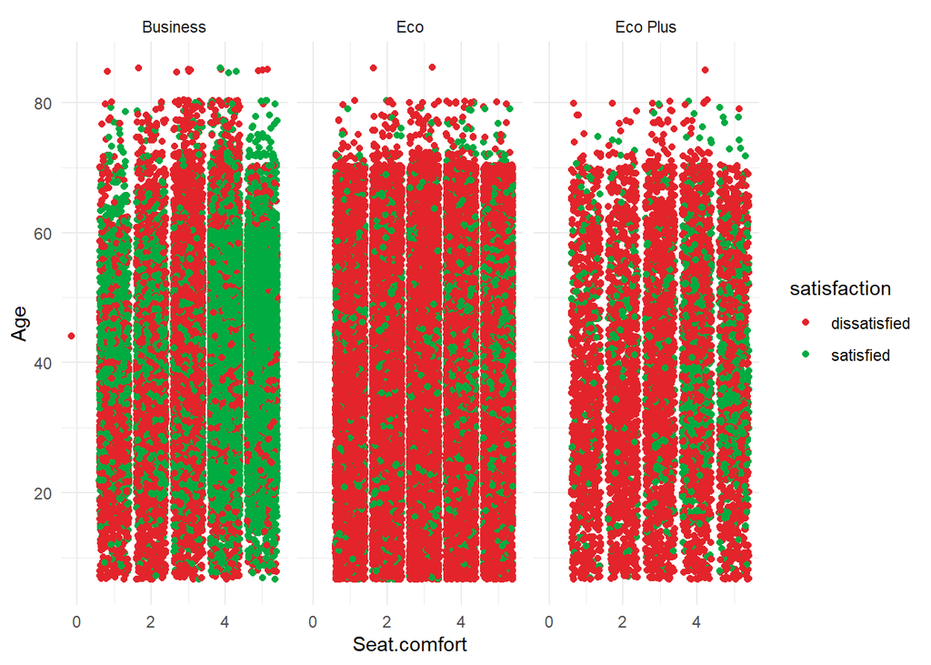

```r
# According to the graph shown above, it is clear that those passengers belonging
# to Business class are the most satisfied ones. By seeing these results, it is
# clear that some improvements must be done in the rest of the classes.
# Moreover, further investigations could be pursued and discover what is that
# causes this big dissatisfaction among the passengers of other classes.


# Q2: We all are passengers, may it be of cars, trains, planes... and we know
# how vital a comfortable seat is. Hence, is this a big influence in the
# passengers' satisfaction? Is this also related to the age and the class?
ggplot(final_dataset) +
  aes(x = Seat.comfort, y = Age, colour = satisfaction) +
  geom_jitter(size = 1.5) +
  scale_color_manual(
    values = c(dissatisfied = "#E3242B",
               satisfied = "#00AB41")
  ) +
  theme_minimal() +
  facet_wrap(vars(Class))
```

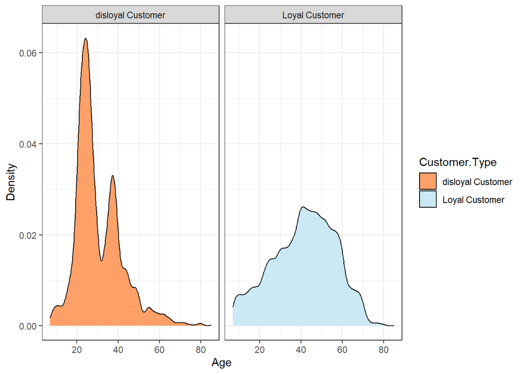

```r
# Several conclusions can be made from this graph:
# 1. The most dissatisfied passengers belong to Eco class, no matter the age.
# 2. The most uncomfortable seats are located in the Eco class.
# 3. As observed, it would be a good recommendation for airlines to upgrade
#    their seats, as passengers tend to prefer a comfortable seat rather than
#    the class.
# 4. The satisfaction does not depend on the age, moreover, we cannot be sure
#    about this, so let's try to figure this out in next questions.


# Q3: Is the the age of the passenger related to the type of customer?
ggplot(final_dataset) +
  aes(x = Age, fill = Customer.Type) +
  geom_density(adjust = 1L) +
  scale_fill_manual(values = c(`disloyal Customer` = "#FFA068",`Loyal Customer` = "#CAE9F5")) +
  labs(y = "Density") +
  theme_bw() +
  facet_wrap(vars(Customer.Type))
```

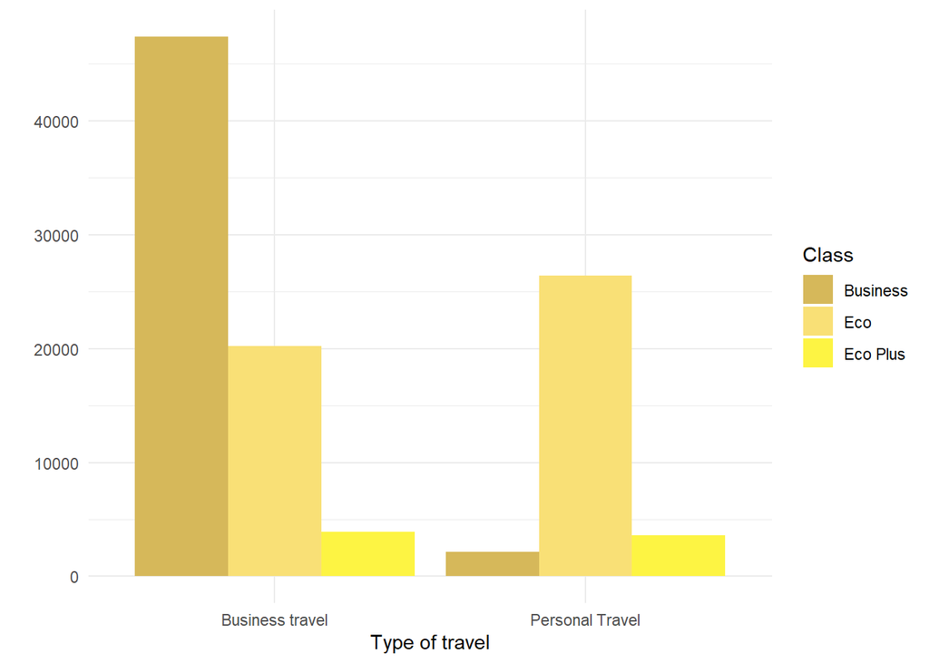

```r
# From very little age to almost 35, and from age 35 to 40, the number of
# disloyal passengers is very high compared to loyal passengers. On the contrary,
# in age range 40 to 60, the number of loyal customers are higher compared to the rest.


# Q4: Is the type of travel related, in a way or another, to the class of the passengers?
ggplot(final_dataset) +
  aes(x = Type.of.Travel, fill = Class) +
  geom_bar(position = "dodge") +
  scale_fill_manual(values = c(Business = "#D6B85A", Eco = "#F9E076", `Eco Plus` = "#FDF443")) +
  labs(x = "Type of travel",y = '') +
  theme_minimal()
```

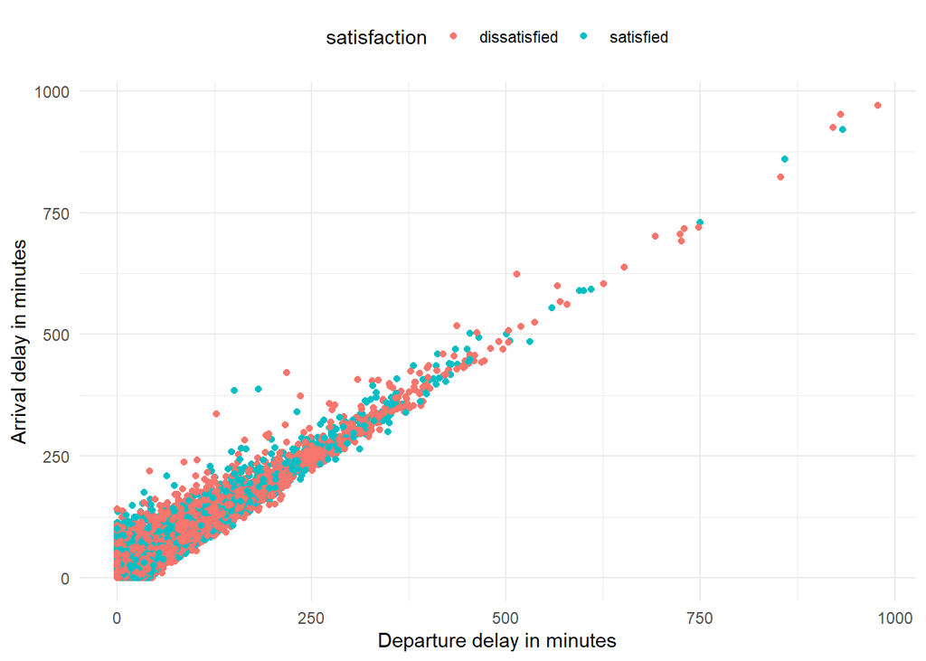

```r
# After an in-depth analysis of the graph exposed above, it is clear that those
# traveling because of business reasons tend to travel in business class, even
# though the number of those traveling in eco and eco plus are almost the same,
# no matter the type of travel.


# Q5: Are the variables Departure.Delay.in.Minutes and Arrival.Delay.in.Minutes
# related to the satisfaction?
final_dataset %>%
 filter(Departure.Delay.in.Minutes >= 0 & Departure.Delay.in.Minutes <= 1000) %>%
 filter(Arrival.Delay.in.Minutes >= 0 & Arrival.Delay.in.Minutes <= 1000) %>%
 ggplot() +
 aes(x = Departure.Delay.in.Minutes, y = Arrival.Delay.in.Minutes, colour = satisfaction) +
 geom_point(shape = "circle", size = 1.5) +
 scale_color_hue(direction = 1) +
 labs(x = "Departure delay in minutes",
 y = "Arrival delay in minutes") +
 theme_minimal() +
 theme(legend.position = "top")
```

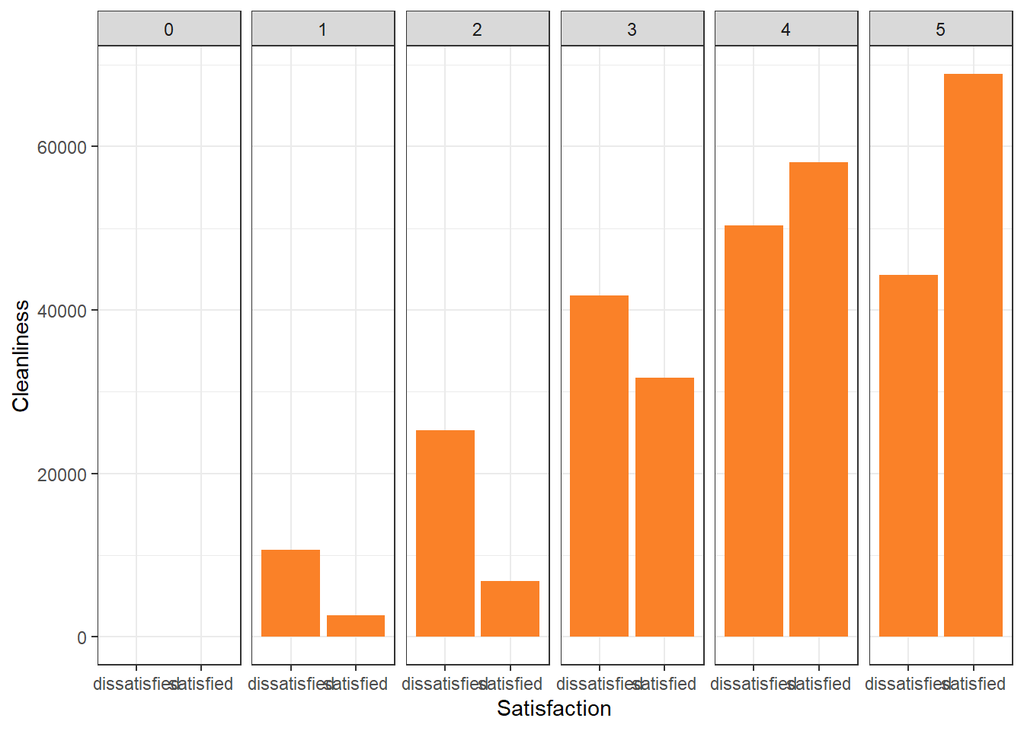

```r
# Indeed, there is a positive linear relationship between the variables.
# Concerning these variables, it is clear that the lower the delay, the more the
# satisfied number of passengers. Nonetheless, even with no delay there are still
# some passengers who are dissatisfied. This may be explained with other variables.


# Q6: Is the satisfaction influenced by the variables Cleanliness, Ease.of.Online.booking,
# Food.and.drink, and Seat.comfort?
ggplot(final_dataset) +
 aes(x = satisfaction, y = Cleanliness) +
 geom_col(fill = "#FA8128") +
 labs(x = "Satisfaction",
 y = "Cleanliness") +
 theme_bw() +
 facet_wrap(vars(Cleanliness), ncol = 6L)
```

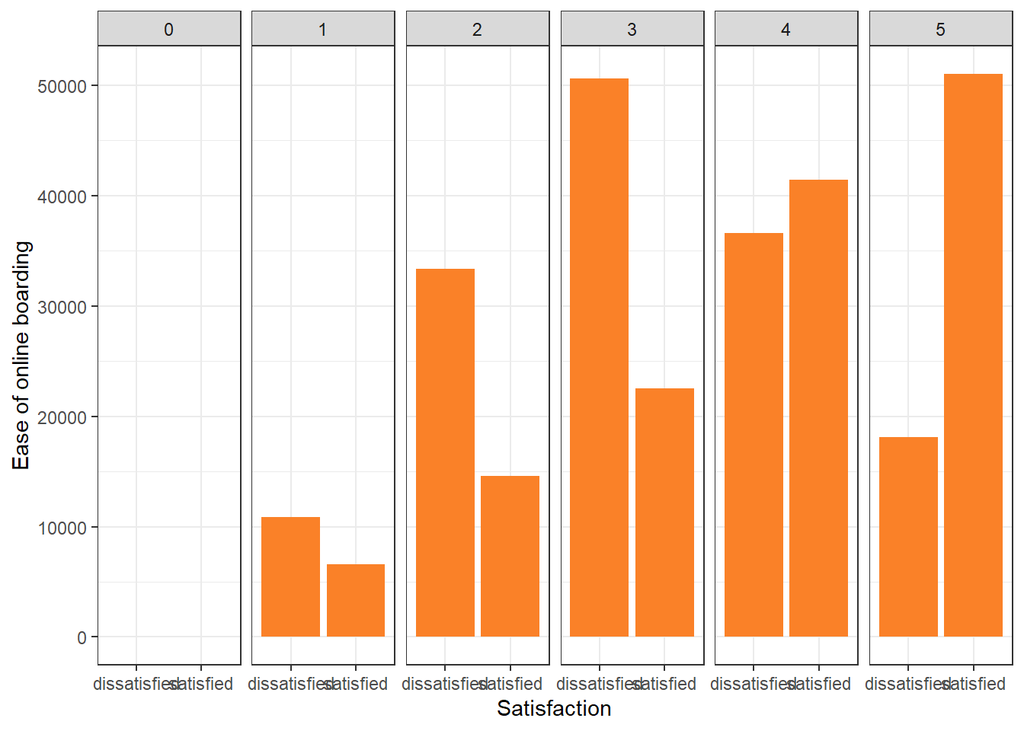

```r
ggplot(final_dataset) +
  aes(x = satisfaction, y = Ease.of.Online.booking) +
  geom_col(fill = "#FA8128") +
  labs(x = "Satisfaction",
       y = "Ease of online boarding") +
  theme_bw() +
  facet_wrap(vars(Ease.of.Online.booking), ncol = 6L)
```

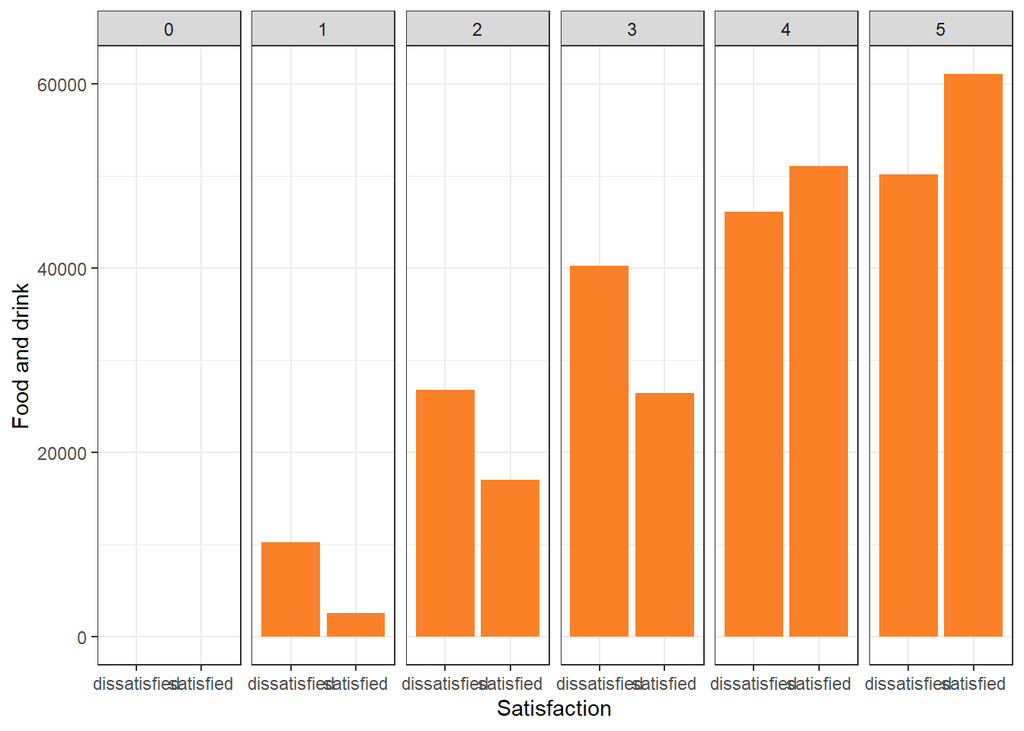

```r
ggplot(final_dataset) +
  aes(x = satisfaction, y = Food.and.drink) +
  geom_col(fill = "#FA8128") +
  labs(x = "Satisfaction",
       y = "Food and drink") +
  theme_bw() +
  facet_wrap(vars(Food.and.drink), ncol = 6L)
```

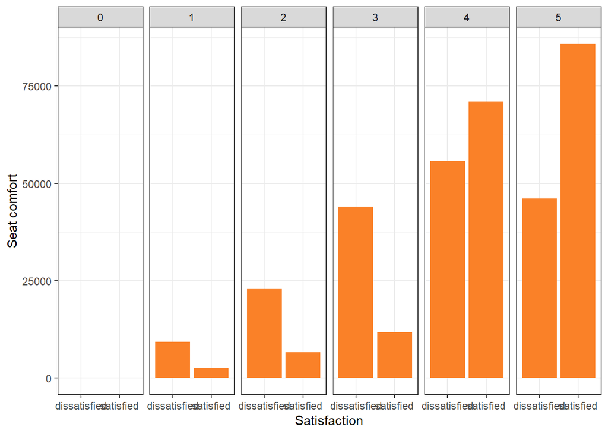

```r
ggplot(final_dataset) +
  aes(x = satisfaction, y = Seat.comfort) +
  geom_col(fill = "#FA8128") +
  labs(x = "Satisfaction",
       y = "Seat comfort") +
  theme_bw() +
  facet_wrap(vars(Seat.comfort), ncol = 6L)
```

```r
# For all these features, the maximum number of satisfied passengers belong to
# categories 4 and 5. Below these, passengers are dissatisfied.
```

# 5 Principal Component Analysis.

Principal component analysis, or PCA, is a technique for reducing the number of dimensions in large data sets by condensing a large collection of variables into a smaller set that retains the majority of the large set’s information. Accuracy naturally suffers as a data set’s variables are reduced, but the answer to dimensionality reduction is to trade a little accuracy for simplicity, since machine learning algorithms can analyze data much more quickly and easily with smaller data sets because there are less unnecessary factors to process. To summarize, the goal of PCA is to minimize the number of variables in a data set while maintaining as much information as possible.

```r
# It is a must to transform all the variables to numeric, since PCA only works
# with these kind of variables. Factor variables are excluded.
data_pca <- final_dataset[c(3, 6:22)]
data_pca <- as.data.frame(sapply(data_pca, as.numeric))
```

## 5.1 STEP 1: Standardization and computation of the eigenvectors and eigenvalues of the covariance matrix.

```r
# Perform PCA and observe the results.
pca <- prcomp(data_pca, scale = TRUE)
summary(pca)
```

```
## Importance of components:
##                           PC1    PC2    PC3    PC4     PC5     PC6     PC7
## Standard deviation     1.9649 1.5373 1.4763 1.4009 1.11586 0.98126 0.96350
## Proportion of Variance 0.2145 0.1313 0.1211 0.1090 0.06917 0.05349 0.05157
## Cumulative Proportion  0.2145 0.3458 0.4668 0.5759 0.64505 0.69855 0.75012
##                            PC8     PC9    PC10    PC11    PC12    PC13    PC14
## Standard deviation     0.94414 0.83156 0.73070 0.69207 0.66848 0.60577 0.56852
## Proportion of Variance 0.04952 0.03842 0.02966 0.02661 0.02483 0.02039 0.01796
## Cumulative Proportion  0.79964 0.83806 0.86772 0.89433 0.91916 0.93954 0.95750
##                           PC15    PC16    PC17    PC18
## Standard deviation     0.54284 0.50071 0.43029 0.18572
## Proportion of Variance 0.01637 0.01393 0.01029 0.00192
## Cumulative Proportion  0.97387 0.98780 0.99808 1.00000
```

## 5.2 STEP 2: Interpret the results.

It is known that PCA firstly extracts the maximum variance and puts it into the first factor. After that, it removes that variance explained by the first factor and then starts extracting maximum variance for the second factor. This process goes to the last factor. How many components is it desired to take? Here, there are several methods to follow:

- 1. Percentage of variance that the components account for. Obtained by calculating the percentage of variation that the major components explain using the cumulative proportion. Then, keep the main factors that account for a reasonable amount of variation. It depends on the purpose of our project, but it may be needed between an 80% to 90% of the variance for descriptive reasons.
- 2. The eigenvalues must be observed. You can use the size of the eigenvalue to determine the number of principal components. Retain the principal components with the largest eigenvalues. For example, using the Kaiser criterion, you use only the principal components with eigenvalues that are greater than 1. These must be above 1, because this means that they explain as much variation as the original variables.
- 3. Scree plot. The scree plot orders the eigenvalues from largest to smallest. The ideal pattern is a steep curve, followed by a bend, and then a straight line. Use the components in the steep curve before the first point that starts the line trend.

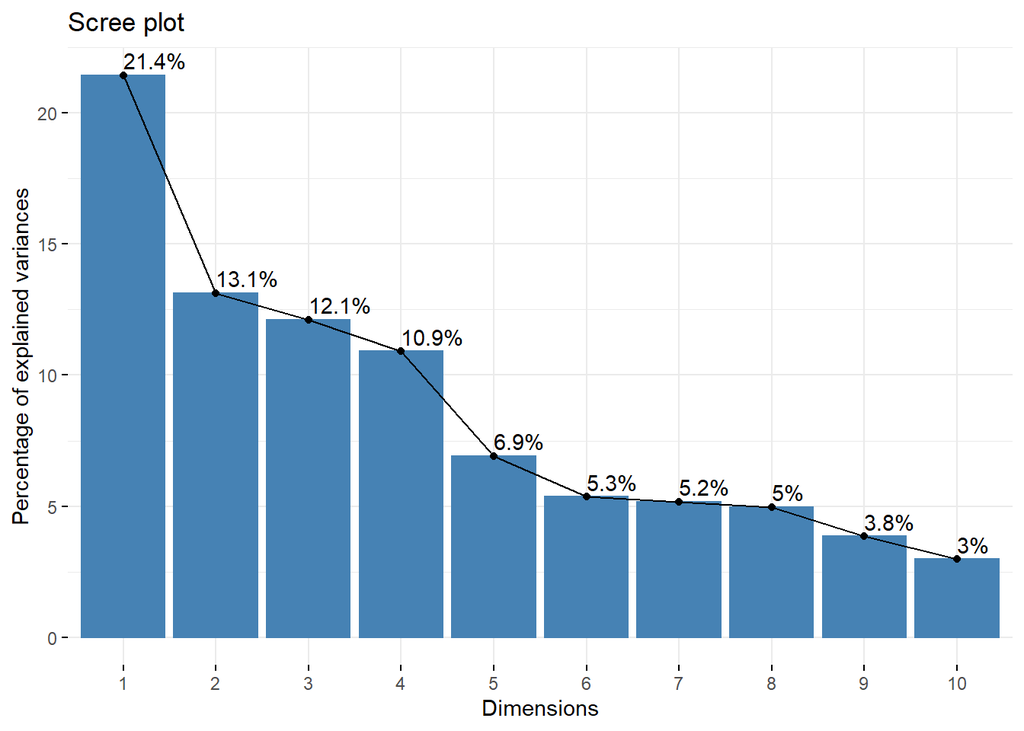

```r
# In our case, scree plot will be used.
fviz_screeplot(pca, addlabels = TRUE)
```

```r
# As the plot shows, by using 4 factors, it would be enough to explain more than 50% of the dataset.
pca$rotation[,1:4]
```

```
##                                           PC1         PC2         PC3
## Age                                0.07120467  0.01012126 -0.10267024
## Flight.Distance                    0.11957453 -0.01979722 -0.01113523
## Inflight.wifi.service              0.23103580  0.44967656 -0.04341691
## Departure.Arrival.time.convenient  0.09918330  0.41742737  0.02621735
## Ease.of.Online.booking             0.16263344  0.53649871 -0.04597711
## Gate.location                      0.06405416  0.43027733 -0.03357226
## Food.and.drink                     0.30215953 -0.15740790 -0.33887851
## Online.boarding                    0.28698476  0.15158750 -0.16991676
## Seat.comfort                       0.34563173 -0.15305620 -0.31386895
## Inflight.entertainment             0.42222447 -0.17727834 -0.06461320
## On.board.service                   0.27455501 -0.07053181  0.37879139
## Leg.room.service                   0.22043041 -0.01409189  0.29502943
## Baggage.handling                   0.25483400 -0.05720561  0.43517739
## Checkin.service                    0.18117271 -0.04862467  0.13163708
## Inflight.service                   0.25874930 -0.06495181  0.44670724
## Cleanliness                        0.35165900 -0.17555336 -0.31212097
## Departure.Delay.in.Minutes        -0.03815949  0.02858195 -0.03766455
## Arrival.Delay.in.Minutes          -0.04078750  0.02840667 -0.03878262
##                                            PC4
## Age                                0.009334937
## Flight.Distance                   -0.021358489
## Inflight.wifi.service              0.013757640
## Departure.Arrival.time.convenient  0.008812775
## Ease.of.Online.booking             0.016076055
## Gate.location                      0.010141601
## Food.and.drink                     0.003791875
## Online.boarding                    0.002118812
## Seat.comfort                      -0.006024007
## Inflight.entertainment            -0.030309268
## On.board.service                  -0.028696730
## Leg.room.service                  -0.066218375
## Baggage.handling                  -0.053156830
## Checkin.service                   -0.012954580
## Inflight.service                  -0.010270936
## Cleanliness                       -0.019326223
## Departure.Delay.in.Minutes        -0.703433692
## Arrival.Delay.in.Minutes          -0.703103717
```